# Validation of synthetic data algorithm

Jason T. Serviss

2018-07-20

```r
#PACKAGES
packages <- c(
  "sp.scRNAseq","sp.scRNAseqData", "sp.scRNAseqTesting",
  "seqTools", "printr", "ggthemes", "tidyverse"
)
purrr::walk(packages, library, character.only = TRUE)
rm(packages)

#FUNCTIONS
#cpm normalization withoit adding 1 that works on both matrices and tibbles with
#genes as rows and cells as columns
norm <- function(counts) {
  if(all(class(counts) == c("tbl_df", "tbl", "data.frame"))) {
    mat <- counts %>%
      as.data.frame() %>%
      column_to_rownames("gene") %>%
      as.matrix()

    t(t(mat) / colSums(mat) * 10^6) %>%
      matrix_to_tibble("gene")
  } else if(class(counts) == "matrix") {
    t(t(counts) / colSums(counts) * 10^6)
  }
}
```

The synthetic multiplets are based on the mixing of real synthetic singlets. The algorithm for generating the synthetic multiplets works as follows: The sum of counts is calculated for each gene in two randomly selected singlets from each cell type contributing to the multiplet. The fraction of input into the multiplet can be adjusted so that, e.g. cell type A only contributes half of what cell type B contributes to the multiplet. A vector is then generated where each gene name is represented one time for each of the total counts (e.g. if gene “A” has a sum of counts from all singlets from the cell types contributing to the multiplet of 10, “A” will be repreated 10 times in the vector). This vector is then sampled without replacment. It is sampled x times, where x is equal to the sum of all the counts in all singlets contributing to the multiplet divided by the total number of singlets contributing to the multiplet. Gene names are then counted which provides the raw counts for the newly synthesized multiplet.

### Synthesize 10 multiplets per combination.

Here we continue to examine the ability of the synthesized multiplets to accuratley reflect the real multiplets by generating 10 multiplets per combination. It is hoped that this will show that the synthesized multiplets as a whole, accuratley capture the diversity of the real multiplets.

```r
s <- str_detect(colnames(countsSorted2), "^s")
sng <- countsSorted2[, s]
classes <- slice(countsSortedMeta2, match(colnames(sng), countsSortedMeta2$sample))$cellTypes
combos <- apply(combn(unique(classes), 2), 2, sort)
adjustment <- rep(1, length(unique(classes)))
names(adjustment) <- unique(classes)

n <- 10
names <- paste(
  apply(combos, 2, paste, collapse = "-"),
  rep(1:n, each = ncol(combos)),
  sep = "."
)

synth <- sng %>%
  norm() %>%
  {map(1:n, function(x) {
    syntheticMultipletsFromCounts(., classes, combos, adjustment, seed = x + 9789)
  })} %>%
  reduce(full_join, by = "gene") %>%
  setNames(c("gene", names)) %>%
  norm()

mul <- countsSorted2[, !s] %>%
  norm() %>%
  matrix_to_tibble("gene") %>%
  gather(sample, counts, -gene) %>%
  left_join(countsSortedMeta2, by = "sample") %>%
  select(gene, counts, cellTypes, sample)
```

Plot results.

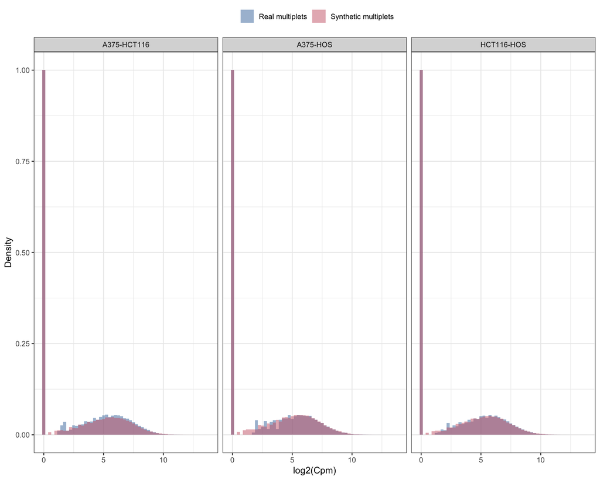

```r
synth %>%
  gather(typeRep, synCounts, -gene) %>%
  separate(typeRep, c("cellTypes", "sample"), sep = "\\.") %>%
  inner_join(., mul, by = c("gene", "cellTypes")) %>%
  gather(type, counts, -(gene:sample.x), -sample.y) %>%
  mutate(counts = log2(counts + 1)) %>%
  mutate(type = if_else(
    type == "counts",
    "Real multiplets",
    "Synthetic multiplets"
  )) %>%
  ggplot() +
  geom_histogram(
    aes(counts, stat(ndensity), fill = type),
    alpha = 0.5, binwidth = 0.25, position = "identity"
  ) +
  facet_wrap(~cellTypes) +
  labs(x = "log2(Cpm)", y = "Density") +
  theme_bw() +
  ggthemes::scale_fill_ptol() +
  guides(fill = guide_legend(title = "")) +
  theme(legend.position = "top")
```

### Adjusting multiplet contribution

Synthesize 25 multiplets for each combination and reduce the contribution of HOS cells by 0%, 25%, 50%, 75%, or 99%. Calculate the mean gene expression for each and plot together with the real multiplets and corresponding singlets.

```r
###FUNCTIONS
#function to calculate the mean gene expression for a specific cell type. Used
#previous to heatmap plotting
typeMeans <- function(type) {
  countsSortedMeta2 %>%
  filter(cellTypes == type) %>%
  pull(sample) %>%
  {countsSorted2[, colnames(countsSorted2) %in% .]} %>%
  norm() %>%
  rowMeans() %>%
  matrix_to_tibble("gene") %>%
  setNames(c("gene", "counts")) %>%
  mutate(cellType = type)
}

#wrapper to generate and reformat multiplets
generateAdjustedMultiplets <- function(sng, classes, combos, adjustment, name) {
  q.name <- enquo(name)
  sng %>%
    norm() %>%
    {map(1:n, function(x) {
      syntheticMultipletsFromCounts(., classes, combos, adjustment, seed = x + 9789)
    })} %>%
    reduce(full_join, by = "gene") %>%
    setNames(c("gene", names)) %>%
    norm() %>%
    gather(cellTypes, !!q.name, -gene) %>%
    mutate(cellTypes = str_replace(cellTypes, "(.*)\\..*", "\\1")) %>%
    group_by(gene, cellTypes) %>%
    summarize(!! quo_name(q.name) := mean(!!q.name)) %>%
    ungroup()
}
###

#Synthesize multiplets with varying levels of adjusted HOS input
s <- str_detect(colnames(countsSorted2), "^s")
sng <- countsSorted2[, s]
classes <- slice(countsSortedMeta2, match(colnames(sng), countsSortedMeta2$sample))$cellTypes
combos <- apply(combn(unique(classes), 2), 2, sort)

adjustment <- rep(1, length(unique(classes)))
names(adjustment) <- unique(classes)
n <- 25
names <- paste(
  apply(combos, 2, paste, collapse = "-"),
  rep(1:n, each = ncol(combos)),
  sep = "."
)

adj <- c(1, 0.75, 0.5, 0.25, 0.01)
synth <- map(adj, function(x) {
  adjustment[names(adjustment) == "HOS"] <- x
  generateAdjustedMultiplets(sng, classes, combos, adjustment, synCounts)
}) %>%
  reduce(inner_join, by = c("gene", "cellTypes")) %>%
  setNames(c("gene", "cellTypes", paste0("HOS reduced ", (1 - adj) * 100, "%")))

#heatmap
#find overexpressed genes in each cell type
genes <- foldChangePerClass(cpm(sng), rename(countsSortedMeta2, class = cellTypes)) %>%
  matrix_to_tibble("gene") %>%
  select(gene, A375, HCT116, HOS) %>%
  gather(cellType, fold, -gene) %>%
  group_by(cellType) %>%
  top_n(25, fold) %>%
  ungroup()

#calculate the mean gene expression for each type of singlet
realSng <- map_dfr(c("A375", "HCT116", "HOS"), typeMeans)

#calculate the mean gene expression for each type of multiplet
#concatenate real singlet, real multiplet, and info for genes corresponding to
#a cell type

real <- map_dfr(c("A375-HCT116", "A375-HOS", "HCT116-HOS"), typeMeans) %>%
  rename(Multiplet = counts, cellTypes = cellType) %>%
  separate(cellTypes, into = c("cellType1", "cellType2"), sep = "-", remove = FALSE) %>%
  inner_join(realSng, by = c("cellType1" = "cellType", "gene" = "gene")) %>%
  inner_join(realSng, by = c("cellType2" = "cellType", "gene" = "gene")) %>%
  inner_join(genes, by = "gene") %>%
  filter(cellType == cellType1 | cellType == cellType2) %>%
  rename(geneType = cellType)
```

```r
#join everything and plot
real %>%
  inner_join(synth, by = c("gene", "cellTypes")) %>%
  gather(type, cpm, -gene, -(geneType:fold), -(cellTypes:cellType2)) %>%
  mutate(type = case_when(
    type == "counts.x" ~ cellType1,
    type == "counts.y" ~ cellType2,
    TRUE ~ type
  )) %>%
  mutate(type = parse_factor(type, levels = c(
      "Multiplet", "HOS reduced 0%", "HOS reduced 25%", "HOS reduced 50%", "HOS reduced 75%", "HOS reduced 99%", "A375", "HCT116", "HOS"
  ))) %>%
  arrange(geneType, fold) %>%
  mutate(plotGene = paste0(gene, " (", geneType, ")")) %>%
  mutate(plotGene = parse_factor(plotGene, levels = unique(plotGene))) %>%
  mutate(cellTypes = parse_factor(cellTypes, levels = c("A375-HOS", "HCT116-HOS", "A375-HCT116"))) %>%
  ggplot() +
  geom_tile(aes(type, plotGene, fill = log2(cpm + 1))) +
  facet_wrap(~cellTypes, scale = "free") +
  viridis::scale_fill_viridis() +
  theme_few() +
  theme(
    axis.text.x = element_text(angle = 90),
    axis.title.x = element_blank(),
    legend.position = "top"
  ) +
  labs(y = "Gene (Cell type)")
```

[output not shown]

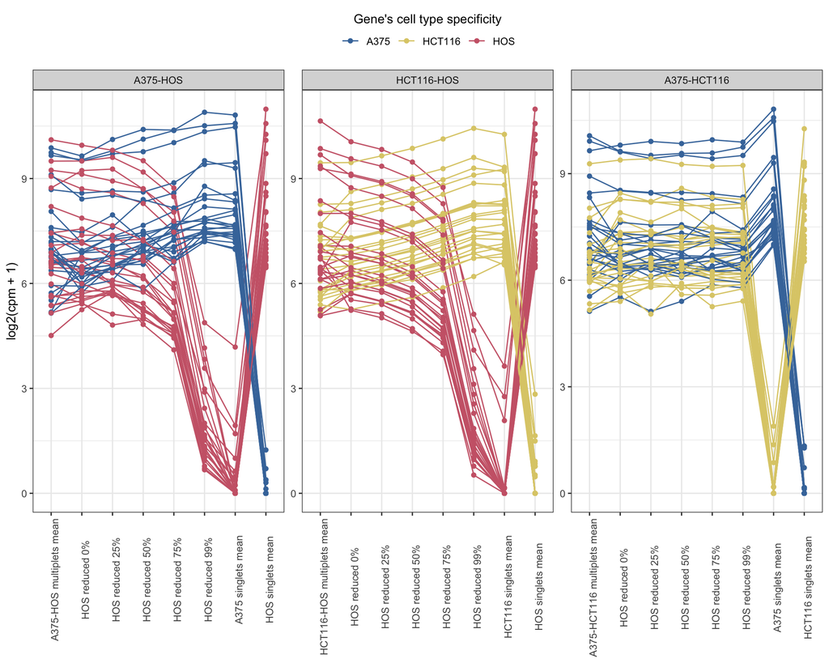

```r
real %>%
  inner_join(synth, by = c("gene", "cellTypes")) %>%
  gather(type, cpm, -gene, -(geneType:fold), -(cellTypes:cellType2)) %>%
  mutate(type = case_when(
    type == "Multiplet" ~ paste0(cellTypes, " multiplets mean"),
    type == "counts.x" ~ paste0(cellType1, " singlets mean"),
    type == "counts.y" ~ paste0(cellType2, " singlets mean"),
    TRUE ~ type
  )) %>%
  mutate(type = parse_factor(type, levels = c(
    "A375-HCT116 multiplets mean", "A375-HOS multiplets mean",
    "HCT116-HOS multiplets mean", "HOS reduced 0%", "HOS reduced 25%",
    "HOS reduced 50%", "HOS reduced 75%", "HOS reduced 99%",
    "A375 singlets mean", "HCT116 singlets mean", "HOS singlets mean"
  ))) %>%
  arrange(geneType, fold) %>%
  mutate(plotGene = paste0(gene, " (", geneType, ")")) %>%
  mutate(plotGene = parse_factor(plotGene, levels = unique(plotGene))) %>%
  mutate(cellTypes = parse_factor(cellTypes, levels = c("A375-HOS", "HCT116-HOS", "A375-HCT116"))) %>%
  ggplot() +
  geom_line(aes(type, log2(cpm + 1), group = gene, colour = geneType)) +
  geom_point(aes(type, log2(cpm + 1), colour = geneType)) +
  facet_wrap(~cellTypes, scales = "free") +
  theme_bw() +
  ggthemes::scale_colour_ptol() +
  theme(
    axis.title.x = element_blank(),
    axis.text.x = element_text(angle = 90),
    legend.position = "top"
  ) +
  guides(colour = guide_legend(
    title = "Gene's cell type specificity",
    title.position = "top",
    title.hjust = 0.5)
  )
```